# Lecture 3: Discrete Parametric Simulations

Catie McVey

2023-09-4

```r
library(tidyverse)
```

```r
library(pheatmap)
```

# Intro

Alright, now that we know how to visually inspect our simulations, so that we can both inspect and communicate our results, lets start to build our toolkit of simulation techniques.

We’re going to start off with parametric simulation techniques. That is ultimately just a fancy way to say that we are going to randomly draw samples from a known distribution that can be explicitely defined by some set of parameters.

Being a programing language specifically geared toward statistical programming, R makes it easy to work with a wide range of statistical distributions. So lets quickly review that syntax. For a given distribution, which will usually be referenced using a shorthand, there are typically four functions availiable.

To see how these work, lets take a look at our old friend the normal distribution

```r
set.seed(61916)

pnorm(0, mean = 0, sd = 1)
```

```
## [1] 0.5
```

```r
qnorm(0.5, mean = 0, sd = 1)
```

```
## [1] 0
```

```r
dnorm(0, mean = 0, sd = 1)
```

```
## [1] 0.3989423
```

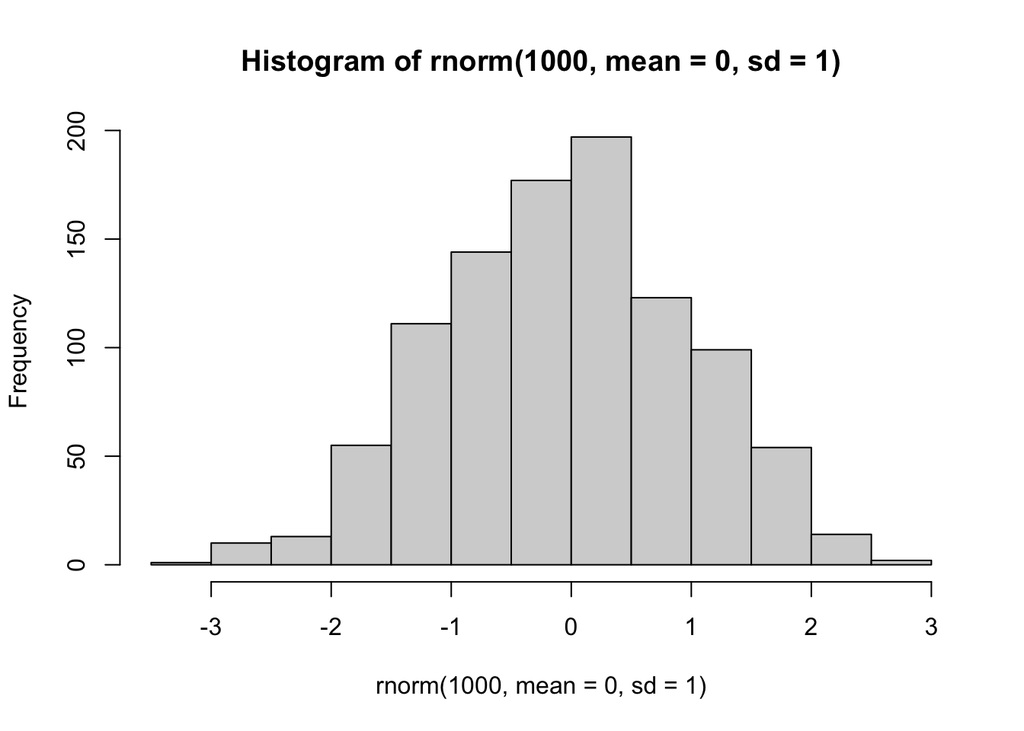

```r
hist(rnorm(1000, mean = 0, sd = 1))
```

You might have noticed in the previous chunk, and in other examples in this class so far, that I’ve called a function called set.seed(), but it doesn’t return anything to the console. So what is it doing. We’re not going to go too deep into the finer details of how R generated random samples in this class, but the basic idea is that under the hood R has a really big table of radom numbers that it can pull from to create a sample. Normally, it starts a radom place in that table, so each pull from the referenace distribution won’t be identical

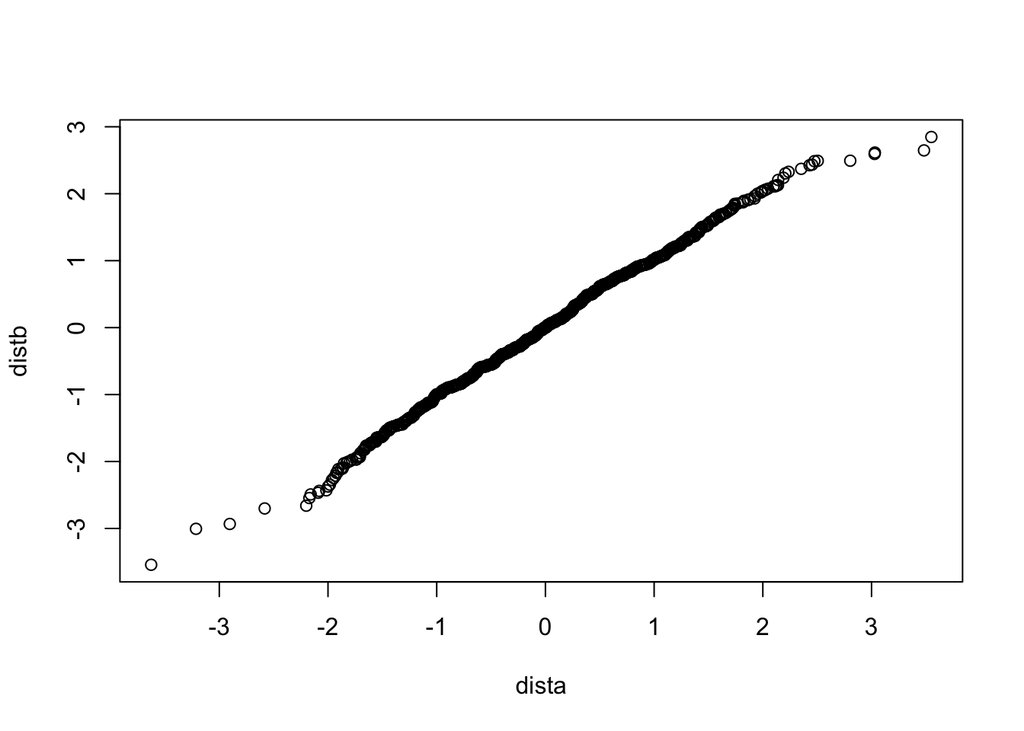

```r
dista <- rnorm(1000, mean = 0, sd = 1)
distb <- rnorm(1000, mean = 0, sd = 1)
qqplot(dista, distb)
```

But that can create a bit of a logistical headache when you try to create reports for a stochastic simulation. You might run everythig in Rstudio, and write about results of your simulations - maybe you get a p value of 0.031. But then when you go to compile the markdow, everything gets rerun from a different position in the random number table, and you get a new pvalue of 0.033 - same inference in this case, but it’ll look sloppy. Or maybe you get a error the first time you run a sim, and then you can’t reproduce it the next three times you run it because its a different sample with different sample. The function set.seed() simply forces R to start at a specific index in its random number table, so that you can get a random sample of points, but it will be the same sample every time. You can put any integer value in - my only warning is don’t be tempted to fiddle with the integer until your get the result you want. That type of p-value phishing is unethical and so its usually best to consistetly use the same numbers in your scripts. For example - I always use palendromes.

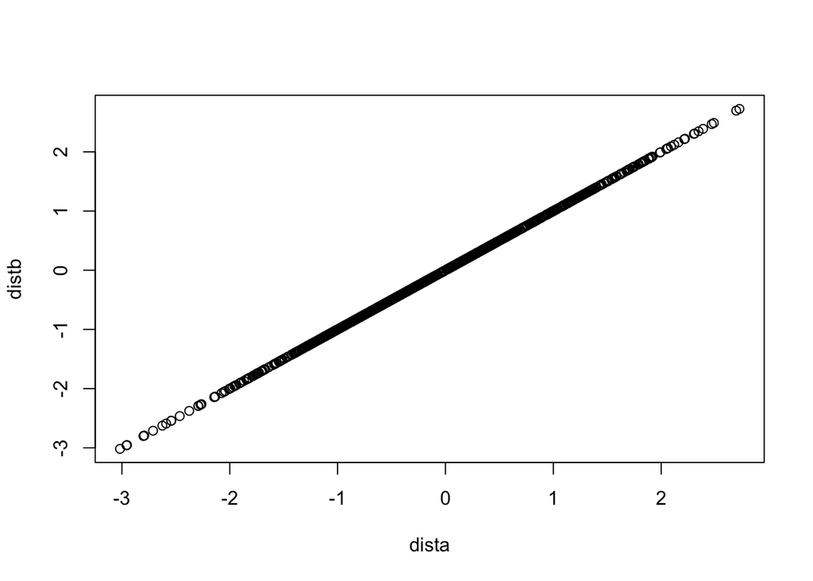

```r
set.seed(61916)
dista <- rnorm(1000, mean = 0, sd = 1)
set.seed(61916)
distb <- rnorm(1000, mean = 0, sd = 1)
qqplot(dista, distb)
```

#Discrete Parametric Distributions

Alright, now that we have understand how to work with distributions in R, lets start to develop a pallete of reference distributions to work with in creating simulations.

We’ll start by covering discrete distributions. Discrete distributions are appropriate for classes of data that can be represented by integers: namely count data and categorical data.

##The ‘Coin Flip Family’ (Binary Trials)

###Bernouli Random Variable